# 4-3 나이브 베이즈, K최근접 이웃

이를 기반으로 spam/ham 을 분류합니다.

```r
# 1. 단어별로 로그 확률 계산
df_word_prob_log <- df_word_prob %>%
  mutate(spam_log = log(spam_prob))

# 2. 문서별로 로그 확률의 합을 계산
s_spam_logprob <- s_spam_words %>%
  inner_join(df_word_prob_log, by = "words") %>%
  group_by(no) %>%
  summarize(log_prob_sum = sum(spam_log, na.rm = TRUE))

# 3. spam일 확률을 더합니다.
s_spam_logprob <- s_spam_logprob %>%
  mutate(spam_log_prob = log_prob_sum + log(s_target_prob["spam"]))

# 결과 출력
s_spam_logprob
```

| no | log_prob_sum | spam_log_prob |
| --- | --- | --- |
| 1 | -88.515187 | -90.521769 |
| 2 | -33.192856 | -35.199438 |
| 3 | -68.779220 | -70.785802 |
| 4 | -42.677705 | -44.684288 |
| 5 | -67.223607 | -69.230190 |
| 6 | -89.774496 | -91.781078 |
| 7 | -47.420350 | -49.426932 |
| 8 | -69.296030 | -71.302612 |
| 9 | -51.471003 | -53.477585 |
| 10 | -56.105132 | -58.111714 |

[output cut: 990 more lines]

```r
# 단어별로 로그 확률 계산
df_word_prob_log <- df_word_prob %>%
  mutate(ham_log = log(ham_prob))

# 문서별로 로그 확률의 합을 계산
s_ham_logprob <- s_spam_words %>%
  inner_join(df_word_prob_log, by = "words") %>%
  group_by(no) %>%
  summarize(log_prob_sum = sum(ham_log, na.rm = TRUE))

# ham일 확률을 더합니다.
s_ham_logprob <- s_ham_logprob %>%
  mutate(ham_log_prob = log_prob_sum + log(s_target_prob["ham"]))

# 결과 출력
s_ham_logprob
```

| no | log_prob_sum | ham_log_prob |
| --- | --- | --- |
| 1 | -77.656836 | -77.801223 |
| 2 | -21.369299 | -21.513686 |
| 3 | -123.997427 | -124.141814 |
| 4 | -29.328367 | -29.472754 |
| 5 | -46.261063 | -46.405450 |
| 6 | -101.072336 | -101.216723 |
| 7 | -40.757054 | -40.901441 |
| 8 | -69.317961 | -69.462348 |
| 9 | -103.188985 | -103.333372 |
| 10 | -103.983363 | -104.127750 |

[output cut: 990 more lines]

```r
# df_spam에 target_prd 열 추가
df_spam_result <- df_spam %>%
  inner_join(s_spam_logprob, by = "no") %>%
  inner_join(s_ham_logprob, by = "no") %>%
  mutate(target_prd = ifelse(spam_log_prob > ham_log_prob, 'spam', 'ham')) %>%
  replace_na(list(target_prd = 'ham'))
df_spam_result
```

| target | message | no | log_prob_sum.x | spam_log_prob | log_prob_sum.y | ham_log_prob | target_prd |
| --- | --- | --- | --- | --- | --- | --- | --- |
| ham | Go until jurong point, crazy.. Available only in bugis n great world la e buffet... Cine there got amore wat... | 1 | -88.515187 | -90.521769 | -77.656836 | -77.801223 | ham |
| ham | Ok lar... Joking wif u oni... | 2 | -33.192856 | -35.199438 | -21.369299 | -21.513686 | ham |
| spam | Free entry in 2 a wkly comp to win FA Cup final tkts 21st May 2005. Text FA to 87121 to receive entry question(std txt rate)T&C's apply 08452810075over18's | 3 | -68.779220 | -70.785802 | -123.997427 | -124.141814 | spam |
| ham | U dun say so early hor... U c already then say... | 4 | -42.677705 | -44.684288 | -29.328367 | -29.472754 | ham |
| ham | Nah I don't think he goes to usf, he lives around here though | 5 | -67.223607 | -69.230190 | -46.261063 | -46.405450 | ham |
| spam | FreeMsg Hey there darling it's been 3 week's now and no word back! I'd like some fun you up for it still? Tb ok! XxX std chgs to send, £1.50 to rcv | 6 | -89.774496 | -91.781078 | -101.072336 | -101.216723 | spam |
| ham | Even my brother is not like to speak with me. They treat me like aids patent. | 7 | -47.420350 | -49.426932 | -40.757054 | -40.901441 | ham |
| ham | As per your request 'Melle Melle (Oru Minnaminunginte Nurungu Vettam)' has been set as your callertune for all Callers. Press *9 to copy your friends Callertune | 8 | -69.296030 | -71.302612 | -69.317961 | -69.462348 | ham |
| spam | WINNER!! As a valued network customer you have been selected to receivea £900 prize reward! To claim call 09061701461. Claim code KL341. Valid 12 hours only. | 9 | -51.471003 | -53.477585 | -103.188985 | -103.333372 | spam |
| spam | Had your mobile 11 months or more? U R entitled to Update to the latest colour mobiles with camera for Free! Call The Mobile Update Co FREE on 08002986030 | 10 | -56.105132 | -58.111714 | -103.983363 | -104.127750 | spam |

[output cut: 990 more lines]

```r
mean(df_spam_result$target == df_spam_result$target_prd)
```

```
[1] 0.9798287
```

- 가법 평활화

$\hat{\theta}_{ci} = \frac{ N_{ci} + \alpha}{N_c + \alpha n}$

> $\alpha$가 작을 수록 평활화가 적게 적용 되어 학습 데이터를 더 반영하고, 클수록 평활화가 크게 적용 되어 학습 데이터를 덜 반영하게 됩니다.

> $N_{ci} = \sum_{i=1}^{c} x_i$ 클래스 c에서 i 속성이 등장한 수입니다.

> $N_{c} = \sum_{i=1}^{n} N_{ci}$ 클래스 c에서 등장한 속성의 총합입니다.

```r
library(e1071)
library(tm)
library(caret)
library(dplyr)

# 훈련 및 테스트 세트 분할
set.seed(123)
train_index <- createDataPartition(df_spam$target, p = 0.8, list = FALSE)
df_train <- df_spam[train_index, ]
df_test <- df_spam[-train_index, ]

F1_Score <- function(pred, actual, positive) {
  # 팩터로 변환하고 동일한 레벨 설정
  levels <- union(levels(factor(pred)), levels(factor(actual)))
  pred <- factor(pred, levels = levels)
  actual <- factor(actual, levels = levels)

  cm <- confusionMatrix(pred, actual, positive = positive)

  precision <- cm$byClass["Pos Pred Value"]
  recall <- cm$byClass["Sensitivity"]
  f1 <- 2 * ((precision * recall) / (precision + recall))

  # NaN 값을 0으로 처리
  if (is.nan(f1)) {
    f1 <- 0
  }

  return(f1)
}


# 텍스트 전처리 함수
text_preprocess <- function(corpus) {
  corpus <- tm_map(corpus, content_transformer(tolower)) # 소문자로 변환
  corpus <- tm_map(corpus, removeNumbers) # 숫자 제거
  corpus <- tm_map(corpus, removePunctuation) # 구두점 제거
  corpus <- tm_map(corpus, removeWords, stopwords("en")) # 불용어 제거
  corpus <- tm_map(corpus, stemDocument) # 어간 추출
  corpus <- tm_map(corpus, stripWhitespace) # 공백 제거
  return(corpus)
}

# 텍스트를 말뭉치로 변환하고 전처리 적용
train_corpus <- VCorpus(VectorSource(df_train$message))
test_corpus <- VCorpus(VectorSource(df_test$message))
train_corpus <- text_preprocess(train_corpus)
test_corpus <- text_preprocess(test_corpus)

# 단어 문서 행렬 생성 (min_df = 5 적용)
dtm_train <- DocumentTermMatrix(train_corpus, control = list(wordLengths = c(1, Inf), bounds = list(global = c(5, Inf))))
dtm_test <- DocumentTermMatrix(test_corpus, control = list(wordLengths = c(1, Inf), bounds = list(global = c(5, Inf))))

# 동일한 단어 집합 사용을 위해 사전 사용
common_terms <- intersect(colnames(dtm_train), colnames(dtm_test))
dtm_train <- dtm_train[, common_terms]
dtm_test <- dtm_test[, common_terms]

# 데이터프레임으로 변환
train_matrix <- as.matrix(dtm_train)
test_matrix <- as.matrix(dtm_test)
df_train_dtm <- data.frame(train_matrix)
df_test_dtm <- data.frame(test_matrix)
df_train_dtm$target <- df_train$target
df_test_dtm$target <- df_test$target

# 나이브 베이즈 분류기 학습
clf_nb <- naiveBayes(target ~ ., data = df_train_dtm, laplace = 1)

# 예측 수행 및 F1 스코어 계산
pred_train <- predict(clf_nb, df_train_dtm)
pred_test <- predict(clf_nb, df_test_dtm)

f1_train <- F1_Score(pred_train, df_train_dtm$target, positive = "spam")
f1_test <- F1_Score(pred_test, df_test_dtm$target, positive = "spam")

# 결과 출력
f1_train
```

```
Pos Pred Value
     0.2501105
```

```r
f1_test
```

```
Pos Pred Value
     0.2464789
```

```r
library(pROC)
# alpha 값들
alphas <- c(0.1, 0.5, 0.8, 1.0, 1.2, 1.5, 2.0)
auc_train <- c()
auc_test <- c()

for (alpha in alphas) {
  # 나이브 베이즈 분류기 학습
  clf_nb <- naiveBayes(target ~ ., data = df_train_dtm, laplace = alpha)

  # 예측 확률 계산
  pred_train_prob <- predict(clf_nb, df_train_dtm, type = "raw")[, "spam"]
  pred_test_prob <- predict(clf_nb, df_test_dtm, type = "raw")[, "spam"]

  # AUC 계산
  auc_train <- c(auc_train, roc(df_train_dtm$target, pred_train_prob)$auc)
  auc_test <- c(auc_test, roc(df_test_dtm$target, pred_test_prob)$auc)
}
# 결과 시각화
plot(alphas, auc_train, type = "b", col = "blue", ylim = c(0, 1), xlab = "alpha", ylab = "AUC", main = "AUC vs. alpha")
lines(alphas, auc_test, type = "b", col = "red")
```

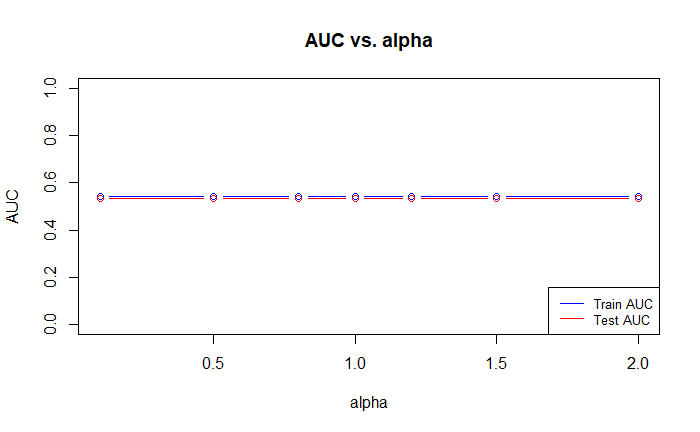

```r
legend("bottomright", legend = c("Train AUC", "Test AUC"), col = c("blue", "red"), lty = 1, cex = 0.8)
```

## 나이브 베이즈의 장단점

### 장점

- 간단하고 학습이 빠릅니다.
- 상대적으로 적은 양의 훈련 데이터로도 효과성이 높습니다.
- 동일한 척도의 여러 속성을 지닌 데이터(ex. 텍스트 분류, 추천…)에 강점이 있습니다.

### 단점

- 조건부 독립이라는 가정이 실제로는 부적절한 경우가 많습니다.

## 2. K 최근접 이웃 모델

K 최근접 이웃은 학습 데이터를 저장해두고, 입력 데이터에서 근접한 K개의 데이터를 뽑아 예측을 합니다.

> 최근접 이웃의 수 K와 근접도를 나타내는 거리 측정 방법이 주요 구성 요소입니다.

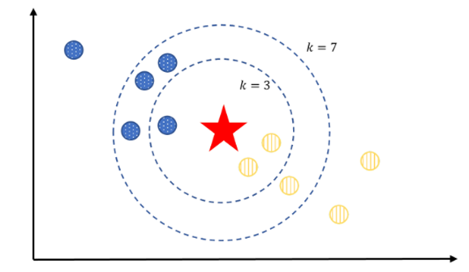

**특징**

최근접 이웃의 수를 늘릴 수록 편향은 증가하고 분산을 감소합니다.

### 분류

K 개의 근접 이웃에 해당하는 학습 데이터에서 다수의 클래스를 예측값으로 합니다.

> 클래스의 수가 동일할 경우에는 전체셋에 대해 다수의 셋을 사용합니다.

### 회귀

K 개의 근접 이웃에 해당하는 대상 변수의 평균을 예측값으로 합니다.

**[Ex.3]**

위 예제에서 모델을 K-최근접 이웃모델로 바꾸고 근접이웃의 수를 아래 리스트에 따라 바꿀 때, df_train과 df_test의 성능 변화를 관찰해봅니다.

성능 측정 지표는 Accuracy입니다.

```
n_neighbors_list = [1, 3, 5, 10, 20, 50, 100]
```

```r
library(class)

# KNN 모델 학습 및 평가
n_neighbors_list <- c(1, 3, 5, 10, 20, 50, 100)
acc_train <- c()
acc_test <- c()

for (k in n_neighbors_list) {
  # KNN 분류기 학습 및 예측
  pred_train <- knn(train = df_train_dtm[, -ncol(df_train_dtm)], test = df_train_dtm[, -ncol(df_train_dtm)], cl = df_train_dtm$target, k = k)
  pred_test <- knn(train = df_train_dtm[, -ncol(df_train_dtm)], test = df_test_dtm[, -ncol(df_test_dtm)], cl = df_train_dtm$target, k = k)

  # 정확도 계산
  acc_train <- c(acc_train, mean(pred_train == df_train_dtm$target))
  acc_test <- c(acc_test, mean(pred_test == df_test_dtm$target))
}
# 결과 시각화
plot(n_neighbors_list, acc_train, type = "b", col = "blue", ylim = c(0, 1), xlab = "Number of Neighbors", ylab = "Accuracy", main = "KNN Accuracy vs. Number of Neighbors")
lines(n_neighbors_list, acc_test, type = "b", col = "red")
```

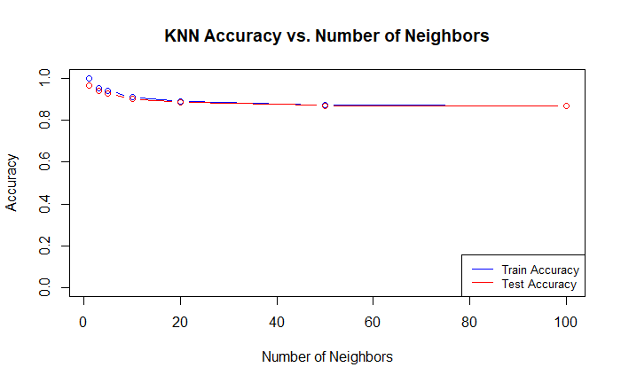

```r
legend("bottomright", legend = c("Train Accuracy", "Test Accuracy"), col = c("blue", "red"), lty = 1, cex = 0.8)
```